# Basic R functions

"Kumar Rahul kumarrah@iimb.ac.in; rahul235@gmail.com

# 1 Basic of R

The examples listed here are to make participants aware of the various features and functionality in R. Particpants can copy and run the example codes in RStudio and should try to interpret the outcome.

## 1.1 Read a csv file

Read data from a csv file. This file contains body height, body weight, HR pulse, BP High and BP low of different patients admitted to a hospital

Whenever, we read a data in R, it is read as Data Frame. You can verify the below one by passing command: `class(raw_df)`

```r
raw_df = read.csv('./files/data.csv')
knitr::kable(head(raw_df))
```

| BODY.WEIGHT | BODY.HEIGHT | HR.PULSE | BP..HIGH | BP.LOW |
| --- | --- | --- | --- | --- |
| 49 | 160 | 118 | 100 | 80 |
| 41 | 155 | 78 | 70 | 50 |
| 47 | 164 | 100 | 110 | 80 |
| 80 | 173 | 122 | 110 | 80 |
| 58 | 175 | 72 | 180 | 100 |
| 45 | 140 | 130 | 215 | 140 |

## 1.2 Calculate Mean

```r
mean_weight = mean(raw_df$BODY.WEIGHT)
cat("The mean weight of ", length(raw_df$BODY.WEIGHT),
    "patients is", round(mean_weight,2),
    "\n") # This is an end-of-line character
```

```
## The mean weight of  163 patients is 39.55
```

## 1.3 Calculate Standard Deviation

```r
st_weight = sd(raw_df$BODY.WEIGHT)
cat("The variation in weight of ", length(raw_df$BODY.WEIGHT),
    "patients is", round(st_weight,2),
    "\n") # This is an end-of-line character
```

```
## The variation in weight of  163 patients is 22.94
```

### 1.3.1 Exercise

**Modify the above code to calculate the mean height and variation of patients**

## 1.4 Correlation

Corelation between height and weight

```r
cor_np = cor(raw_df$BODY.HEIGHT,raw_df$BODY.WEIGHT)
cat("Correlation of height vs weight is", "\n",
    round(cor_np, 2))
```

```
## Correlation of height vs weight is
##  0.85
```

## 1.5 User defined functions

Here’s how you write a function of your own. A function’s graph is a pair (x, f(x))

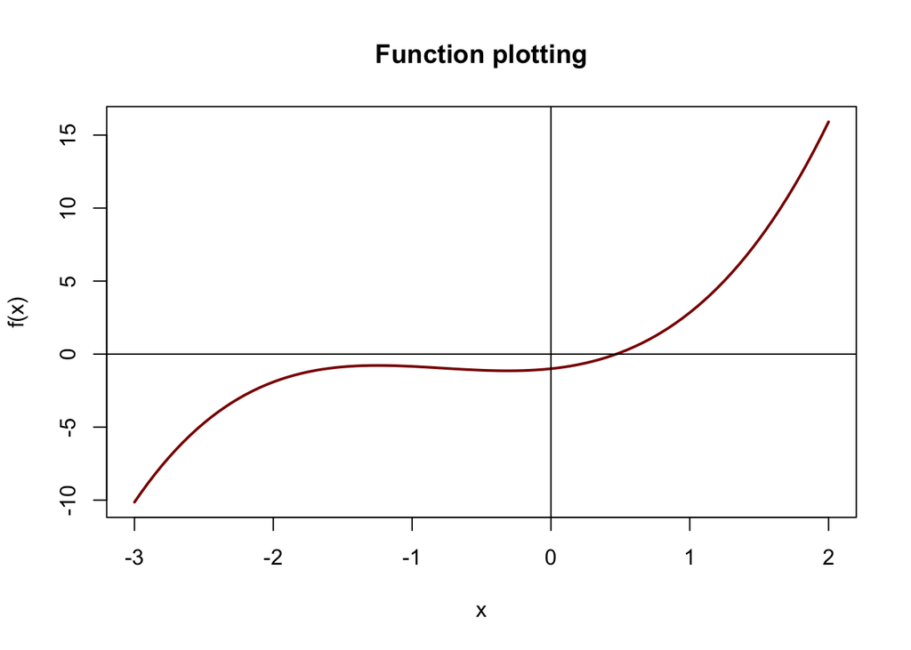

```r
# Simple polynomial
funx = function(x) {
  return (x^3 + 2*x^2 + sin(x) - 1)
}

# x coordinate for the pair
xvals = seq(-3, 2, by=0.05)

# Plot the function
plot(xvals, funx(xvals),
     main="Function plotting",
     type="l", lwd=2,
     col="darkred",
     xlab="x", ylab="f(x)")

# Axes
abline(v=0)
abline(h=0)
```

## 1.6 Create matrix - Optional

Optional topic.

```r
# Create a matrix with names for rows and columns
rownames = c("1st Row", "2nd Row")
colnames = c("1st Col","2nd Col","3rd Col")
A = matrix(c(1,2,3,4,5,6), nrow=2,
            dimnames=list(rownames, colnames))

# Access rows and columns
cat("The first row is", A[1, ], "\n")
```

```
## The first row is 1 3 5
```

```r
cat("The second column is", A[, 2], "\n")
```

```
## The second column is 3 4
```

```r
# Submatrices
B = A[, c(2,3)]
print(B)
```

```
##         2nd Col 3rd Col
## 1st Row       3       5
## 2nd Row       4       6
```

Here’s an easy way to build a matrix of any order

- If m = no. of rows, n = no. of cols, then order = mn

Let’s build a 4 x 5 matrix now

```r
C = matrix(c(1:20), nrow=4)
cat("Column-wise filled 4 x 5 matrix is...\n")
```

```
## Column-wise filled 4 x 5 matrix is...
```

```r
print(C)
```

```
##      [,1] [,2] [,3] [,4] [,5]
## [1,]    1    5    9   13   17
## [2,]    2    6   10   14   18
## [3,]    3    7   11   15   19
## [4,]    4    8   12   16   20
```

Let’s fill the entries row-wise

```r
D = matrix(c(1:20), nrow=4, byrow=TRUE)
cat("Row-wise filled 4 x 5 matrix is...\n")
```

```
## Row-wise filled 4 x 5 matrix is...
```

```r
print(D)
```

```
##      [,1] [,2] [,3] [,4] [,5]
## [1,]    1    2    3    4    5
## [2,]    6    7    8    9   10
## [3,]   11   12   13   14   15
## [4,]   16   17   18   19   20
```

```r
# Let's now build an array of 60 elements
E = array(c(1:60), dim=c(3,4,5))

# Watch what happens when you print this out!
cat("Contents of 3 x 4 x 5 array\n")
```

```
## Contents of 3 x 4 x 5 array
```

```r
print(E)
```

```
## , , 1
##
##      [,1] [,2] [,3] [,4]
## [1,]    1    4    7   10
## [2,]    2    5    8   11
## [3,]    3    6    9   12
##
## , , 2
##
##      [,1] [,2] [,3] [,4]
## [1,]   13   16   19   22
## [2,]   14   17   20   23
## [3,]   15   18   21   24
##
## , , 3
##
##      [,1] [,2] [,3] [,4]
## [1,]   25   28   31   34
## [2,]   26   29   32   35
## [3,]   27   30   33   36
##
## , , 4
##
##      [,1] [,2] [,3] [,4]
## [1,]   37   40   43   46
## [2,]   38   41   44   47
## [3,]   39   42   45   48
##
## , , 5
##
##      [,1] [,2] [,3] [,4]
## [1,]   49   52   55   58
## [2,]   50   53   56   59
## [3,]   51   54   57   60
```

## 1.7 Plot - Scatterplot

Here’s a plot for body height vs body weight. ggplot gives more flexibility and is easy to use compared to the basic plot function which we have used here.

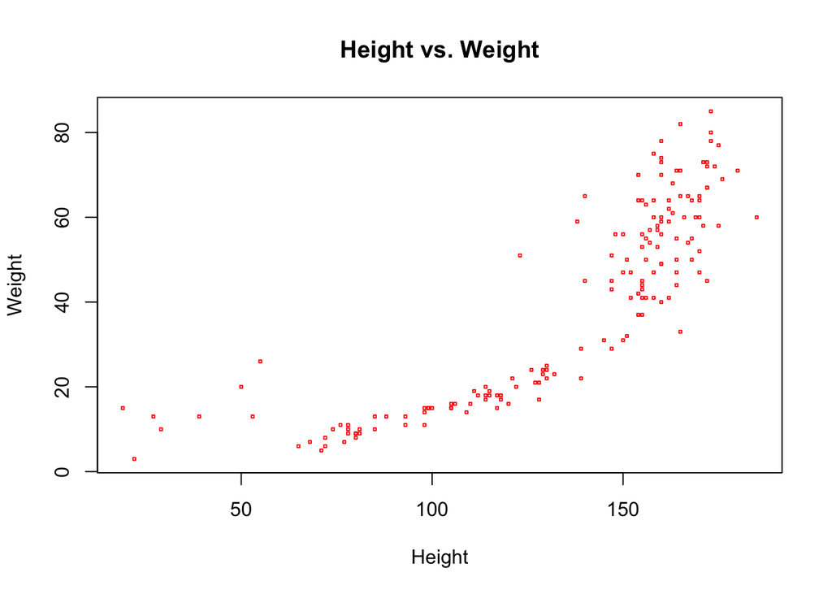

```r
#first plot
plot_1 = function(raw_df) {
  plot(raw_df$BODY.HEIGHT,raw_df$BODY.WEIGHT,
       type = "p",
       pch=.1, #controls the shape
       cex=.3,#controls the size
       col=c("red"),
       main="Height vs. Weight",
       xlab = "Height",
       ylab = "Weight")
}

plot_1(raw_df)
```

Plot of BP high and BP low

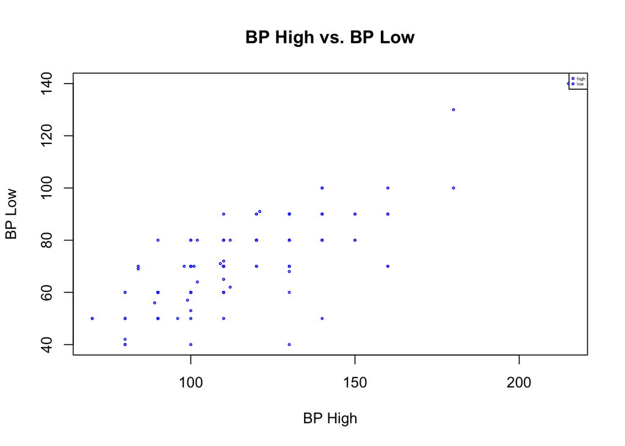

```r
plot_2 = function(raw_df) {
  plot(raw_df$BP..HIGH,raw_df$BP.LOW,
       type = "p",
       pch=1, #controls the shape
       cex=.3,#controls the size
       col=c("blue"),
       main="BP High vs. BP Low",
       xlab = "BP High",
       ylab = "BP Low")
  legend("topright", # places a legend at the appropriate place
         c("high","low"), # puts text in the legend
         pch=1, #controls the shape
         cex=.3,#controls the size,
         col=c("blue"))
}
plot_2(raw_df)
```

### 1.7.1 Plot in Same window - Optional

More about `par()` at https://www.rdocumentation.org/packages/graphics/versions/3.5.1/topics/par

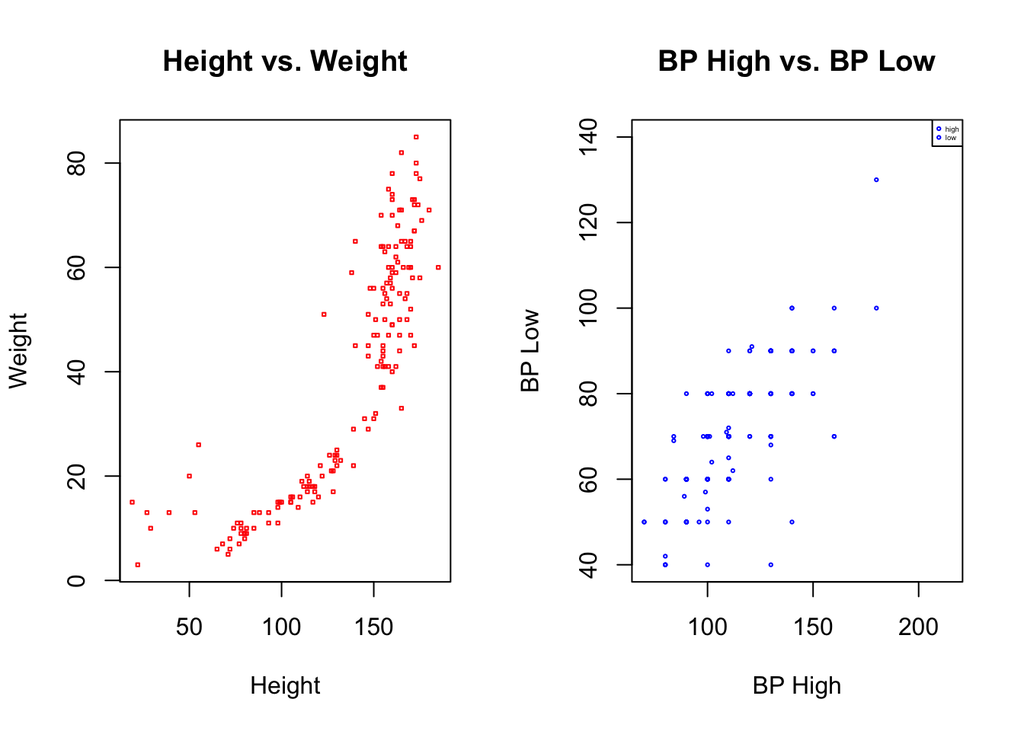

```r
par(mfrow=c(1,2)) # set the plotting area into a 1*2 array
plot_1(raw_df)
plot_2(raw_df)
```

## 1.8 JSON file

Reading a JSON column in a csv file

```r
df <- data.frame(name = "Test1",
           published_date = "1151367060",
           ratings ="[{'id': 7, 'name': 'Funny', 'count': 19645}, {'id': 1, 'name': 'Beautiful', 'count': 4573}, {'id': 9, 'name': 'Ingenious', 'count': 6073}, {'id': 3, 'name': 'Courageous', 'count': 3253}, {'id': 11, 'name': 'Longwinded', 'count': 387}, {'id': 2, 'name': 'Confusing', 'count': 242}, {'id': 8, 'name': 'Informative', 'count': 7346}, {'id': 22, 'name': 'Fascinating', 'count': 10581}, {'id': 21, 'name': 'Unconvincing', 'count': 300}, {'id': 24, 'name': 'Persuasive', 'count': 10704}, {'id': 23, 'name': 'Jaw-dropping', 'count': 4439}, {'id': 25, 'name': 'OK', 'count': 1174}, {'id': 26, 'name': 'Obnoxious', 'count': 209}, {'id': 10, 'name': 'Inspiring', 'count': 24924}]",
           stringsAsFactors = FALSE)

knitr::kable(df)
```

| name | published_date | ratings |
| --- | --- | --- |
| Test1 | 1151367060 | [{‘id’: 7, ‘name’: ‘Funny’, ‘count’: 19645}, {‘id’: 1, ‘name’: ‘Beautiful’, ‘count’: 4573}, {‘id’: 9, ‘name’: ‘Ingenious’, ‘count’: 6073}, {‘id’: 3, ‘name’: ‘Courageous’, ‘count’: 3253}, {‘id’: 11, ‘n… |

Seperate the key value pairs

```r
library(jsonlite)
library(dplyr)
library(tidyr)

listed_df =  mutate(df,
    # replace single quote
    ratings = gsub("'", "\"", ratings),
    # create a list column with the result
    ratings= list(jsonlite::fromJSON(ratings))
  )
new_df = unnest(listed_df)
```

## 1.9 Reading multiple files

```r
setwd("/Users/Rahul/Documents/Datasets")
temp = list.files(pattern="*.csv")
myfiles = lapply(temp, read.csv)
knitr::kable(head(myfiles[[1]]))
```

| SNO | age | job | job_relevel | marital | education | default | balance | housing | persoanl.loan | contact | day | month | duration | campaign | pdays | previous | poutcome | y | Predicted_probability |
| --- | --- | --- | --- | --- | --- | --- | --- | --- | --- | --- | --- | --- | --- | --- | --- | --- | --- | --- | --- |
| 1 | 30 | unemployed | unemployed | married | primary | no | 1787 | no | no | cellular | 19 | oct | 79 | 1 | -1 | 0 | unknown | no | 0.09575 |
| 2 | 33 | services | others | married | secondary | no | 4789 | yes | yes | cellular | 11 | may | 220 | 1 | 339 | 4 | failure | no | 0.06208 |
| 3 | 35 | management | management | single | tertiary | no | 1350 | yes | no | cellular | 16 | apr | 185 | 1 | 330 | 1 | failure | no | 0.14936 |
| 4 | 30 | management | management | married | tertiary | no | 1476 | yes | yes | unknown | 3 | jun | 199 | 4 | -1 | 0 | unknown | no | 0.03219 |
| 5 | 59 | blue-collar | blue-collar | married | secondary | no | 0 | yes | no | unknown | 5 | may | 226 | 1 | -1 | 0 | unknown | no | 0.10549 |
| 6 | 35 | management | management | single | tertiary | no | 747 | no | no | cellular | 23 | feb | 141 | 2 | 176 | 3 | failure | no | 0.28103 |

```r
a_df = myfiles[[1]]
knitr::kable(head(a_df))
```

| SNO | age | job | job_relevel | marital | education | default | balance | housing | persoanl.loan | contact | day | month | duration | campaign | pdays | previous | poutcome | y | Predicted_probability |
| --- | --- | --- | --- | --- | --- | --- | --- | --- | --- | --- | --- | --- | --- | --- | --- | --- | --- | --- | --- |
| 1 | 30 | unemployed | unemployed | married | primary | no | 1787 | no | no | cellular | 19 | oct | 79 | 1 | -1 | 0 | unknown | no | 0.09575 |
| 2 | 33 | services | others | married | secondary | no | 4789 | yes | yes | cellular | 11 | may | 220 | 1 | 339 | 4 | failure | no | 0.06208 |
| 3 | 35 | management | management | single | tertiary | no | 1350 | yes | no | cellular | 16 | apr | 185 | 1 | 330 | 1 | failure | no | 0.14936 |
| 4 | 30 | management | management | married | tertiary | no | 1476 | yes | yes | unknown | 3 | jun | 199 | 4 | -1 | 0 | unknown | no | 0.03219 |
| 5 | 59 | blue-collar | blue-collar | married | secondary | no | 0 | yes | no | unknown | 5 | may | 226 | 1 | -1 | 0 | unknown | no | 0.10549 |
| 6 | 35 | management | management | single | tertiary | no | 747 | no | no | cellular | 23 | feb | 141 | 2 | 176 | 3 | failure | no | 0.28103 |

```r
b_df = myfiles[[2]]
knitr::kable(head(b_df))
```

| Age | Gender | OwnHome | Married | Close | Children | History | Catalogs | AmountSpent | Salary |
| --- | --- | --- | --- | --- | --- | --- | --- | --- | --- |
| L30 | F | NO | NO | YES | 1 | M | 12 | 218 | 16400 |
| B30-55 | F | YES | YES | NO | 3 | H | 18 | 2632 | 108100 |
| B30-55 | M | YES | YES | YES | 1 | NA | 12 | 3048 | 97300 |
| 56+ | M | YES | YES | YES | 0 | L | 12 | 435 | 26800 |
| L30 | M | NO | NO | YES | 0 | NA | 6 | 106 | 11200 |
| B30-55 | F | NO | NO | YES | 0 | M | 12 | 759 | 42800 |

# 2 Summarize Stock Market Data

We will use pfizer data in this section.

- Install the lubridate package
- Open pfizer_df data: https://in.finance.yahoo.com/quote/PFE/
- Read daily data from 1st June 1972 to Current Date. Download as csv

```r
library(lubridate)
pfizer_df = read.csv('./files/PFE.csv', header=TRUE)
```

## 2.1 Head and Tail function

The first six observations

```r
knitr::kable(head(pfizer_df))
```

| Date | Open | High | Low | Close | Adj.Close | Volume |
| --- | --- | --- | --- | --- | --- | --- |
| 1972-06-01 | 0.000000 | 0.859375 | 0.846354 | 0.859375 | 0.000600 | 2332800 |
| 1972-06-02 | 0.859375 | 0.861979 | 0.846354 | 0.848958 | 0.000593 | 1531200 |
| 1972-06-05 | 0.848958 | 0.851563 | 0.841146 | 0.846354 | 0.000591 | 2452800 |
| 1972-06-06 | 0.846354 | 0.869792 | 0.843750 | 0.864583 | 0.000604 | 2227200 |
| 1972-06-07 | 0.864583 | 0.864583 | 0.851563 | 0.864583 | 0.000604 | 979200 |
| 1972-06-08 | 0.864583 | 0.867188 | 0.859375 | 0.859375 | 0.000600 | 1012800 |

The last six observations

```r
knitr::kable(tail(pfizer_df))
```

|  | Date | Open | High | Low | Close | Adj.Close | Volume |
| --- | --- | --- | --- | --- | --- | --- | --- |
| 11998 | 2019-12-26 | 39.30 | 39.57 | 39.20 | 39.38 | 39.38 | 8903300 |
| 11999 | 2019-12-27 | 39.43 | 39.62 | 39.25 | 39.32 | 39.32 | 9599300 |
| 12000 | 2019-12-30 | 39.30 | 39.42 | 38.89 | 38.91 | 38.91 | 10962300 |
| 12001 | 2019-12-31 | 38.79 | 39.20 | 38.71 | 39.18 | 39.18 | 14398200 |
| 12002 | 2020-01-02 | 39.30 | 39.35 | 38.88 | 39.14 | 39.14 | 15668000 |
| 12003 | 2020-01-03 | 38.72 | 39.24 | 38.67 | 38.93 | 38.93 | 14158300 |

## 2.2 Structure of Data

```r
str(pfizer_df)
```

```
## 'data.frame':    12003 obs. of  7 variables:
##  $ Date     : chr  "1972-06-01" "1972-06-02" "1972-06-05" "1972-06-06" ...
##  $ Open     : num  0 0.859 0.849 0.846 0.865 ...
##  $ High     : num  0.859 0.862 0.852 0.87 0.865 ...
##  $ Low      : num  0.846 0.846 0.841 0.844 0.852 ...
##  $ Close    : num  0.859 0.849 0.846 0.865 0.865 ...
##  $ Adj.Close: num  0.0006 0.000593 0.000591 0.000604 0.000604 0.0006 0.000604 0.000606 0.000611 0.000611 ...
##  $ Volume   : int  2332800 1531200 2452800 2227200 979200 1012800 1483200 1843200 2064000 1963200 ...
```

## 2.3 Typecasting

```r
print(paste("The initial type of Date is", class(pfizer_df$Date)))
```

```
## [1] "The initial type of Date is character"
```

```r
print("Converting the Date column to date type")
```

```
## [1] "Converting the Date column to date type"
```

```r
pfizer_df$Date = as.Date(pfizer_df$Date, "%Y-%m-%d")
```

## 2.4 Create new variable

Create month and year as two new columns.

```r
pfizer_df$Month = as.factor(month(pfizer_df$Date))
pfizer_df$Year = year(pfizer_df$Date)
```

## 2.5 Summary Statistics

```r
summary(pfizer_df)
```

```
##       Date                 Open             High              Low
##  Min.   :1972-06-01   Min.   : 0.000   Min.   : 0.4688   Min.   : 0.4505
##  1st Qu.:1984-04-17   1st Qu.: 1.599   1st Qu.: 1.6172   1st Qu.: 1.5781
##  Median :1996-03-01   Median :11.125   Median :11.2708   Median :11.0000
##  Mean   :1996-03-10   Mean   :15.793   Mean   :15.9588   Mean   :15.6214
##  3rd Qu.:2008-02-02   3rd Qu.:30.100   3rd Qu.:30.3700   3rd Qu.:29.7300
##  Max.   :2020-01-03   Max.   :49.729   Max.   :50.0417   Max.   :48.8333
##
##      Close           Adj.Close            Volume              Month
##  Min.   : 0.4505   Min.   : 0.00033   Min.   :        0   8      :1065
##  1st Qu.: 1.6016   1st Qu.: 0.00157   1st Qu.:  6255600   10     :1063
##  Median :11.1042   Median : 4.78978   Median : 11838000   3      :1027
##  Mean   :15.7926   Mean   :10.05849   Mean   : 17636361   6      :1026
##  3rd Qu.:30.0500   3rd Qu.:17.76794   3rd Qu.: 23291650   7      :1013
##  Max.   :50.0417   Max.   :44.57500   Max.   :289735900   12     :1010
##                                                           (Other):5799
##       Year
##  Min.   :1972
##  1st Qu.:1984
##  Median :1996
##  Mean   :1996
##  3rd Qu.:2008
##  Max.   :2020
##
```

## 2.6 Cross Tabulation

table uses the cross-classifying factors to build a contingency table of the counts at each combination of factor levels.

```r
table(pfizer_df$Month)
```

```
##
##    1    2    3    4    5    6    7    8    9   10   11   12
##  980  901 1027  971  996 1026 1013 1065  973 1063  978 1010
```

## 2.7 Subset data

```r
May2017 = subset(pfizer_df,
                    Month == 5 &
                    Year == 2017,
                    select = c(Date, Adj.Close))
knitr::kable(head(May2017))
```

|  | Date | Adj.Close |
| --- | --- | --- |
| 11329 | 2017-05-01 | 30.56518 |
| 11330 | 2017-05-02 | 30.41136 |
| 11331 | 2017-05-03 | 30.28469 |
| 11332 | 2017-05-04 | 30.26659 |
| 11333 | 2017-05-05 | 30.29373 |
| 11334 | 2017-05-08 | 30.26659 |

## 2.8 Plot the data

Graph the time series, using plot function. Better option is to use ggplot package.

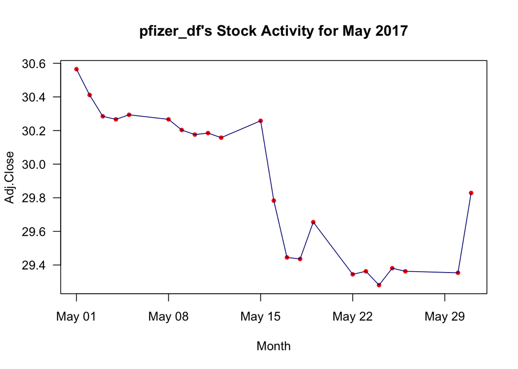

```r
oldPars = par(no.readonly=TRUE)
par(bg="white")
par(lty="solid")

with(May2017, {
  plot(Date, Adj.Close,
       col="red",
       xlab="Month",
       las=1,
       pch=20) # symbol type
  lines(Date, Adj.Close, col="navy")
  title("pfizer_df's Stock Activity for May 2017")
})
```

Restore the old parameter settings

```r
par(oldPars)
```

## 2.9 Exercise

- Open apple_df data: https://in.finance.yahoo.com/quote/AAPL/.
- Read daily data from 12/12/1980 till Current Date. Download as csv.
- Apply all the functions learned in this section.
- Plot the trend for Ajd.Close for Feb2016.

## 2.10 Overlay two plots - Optional

**Optional topic**. We will use the pfizer_df data for the demo.

Step 1: Focus on April stock activities for two years. Express it as a classic time series

```r
Apr2017 = subset(pfizer_df,
                    month(Date) == 4 &
                    year(Date) == 2017,
                    select = c(Date, Adj.Close))

Apr2016 = subset(pfizer_df,
                  month(Date) == 4 &
                  year(Date) == 2016,
                  select = c(Date, Adj.Close))

knitr::kable(head(Apr2017))
```

|  | Date | Adj.Close |
| --- | --- | --- |
| 11310 | 2017-04-03 | 30.98141 |
| 11311 | 2017-04-04 | 31.07189 |
| 11312 | 2017-04-05 | 30.93616 |
| 11313 | 2017-04-06 | 30.86377 |
| 11314 | 2017-04-07 | 30.85473 |
| 11315 | 2017-04-10 | 30.80044 |

```r
knitr::kable(head(Apr2016))
```

|  | Date | Adj.Close |
| --- | --- | --- |
| 11057 | 2016-04-01 | 26.18714 |
| 11058 | 2016-04-04 | 26.77993 |
| 11059 | 2016-04-05 | 27.33784 |
| 11060 | 2016-04-06 | 28.70648 |
| 11061 | 2016-04-07 | 28.55828 |
| 11062 | 2016-04-08 | 28.33163 |

Step 2: Set the options for the plot, after making a copy of the old settings

```r
oldPars = par(no.readonly=TRUE)
```

Step 3: Graph the two time series

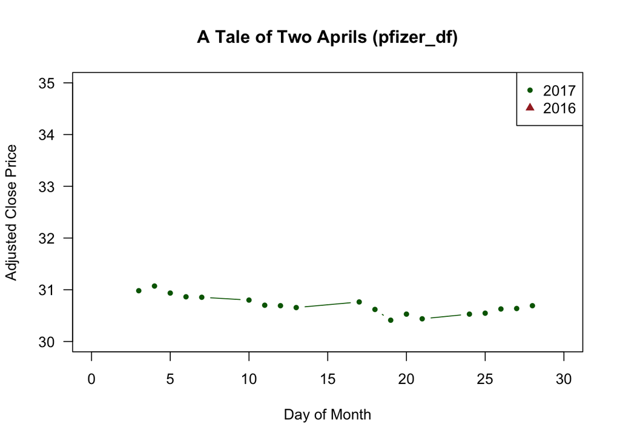

```r
par(lty="solid")
with(Apr2017, {
  plot(day(Date), Adj.Close,
       las=1,
       xlim=c(0, 30),
       ylim=c(30, 35),
       xlab="Day of Month",
       ylab="Adjusted Close Price",
       type="b",
       col="darkgreen",
       pch=20) # symbol type
  title("A Tale of Two Aprils (pfizer_df)")
})

#Prompt to overlay the second plot
par(new=TRUE)

with(Apr2016, {
  plot(day(Date), Adj.Close,
       xlim=c(0, 30),
       ylim=c(30,35), # Must be the same as earlier
       ann=FALSE, # Suppress annotating the axes
       axes=FALSE,
       type="b",
       col="brown",
       cex=0.7,
       pch=17) # symbol type
})


#Now add a legend
legend("topright",
       c("2017","2016"),
       pch=c(20, 17),
       col=c("darkgreen", "brown"))
```

Step 4: Restore the old parameter settings

```r
par(oldPars)
```

## 2.11 Time Series Plot

We will use pfizer_df data for Time Series plot

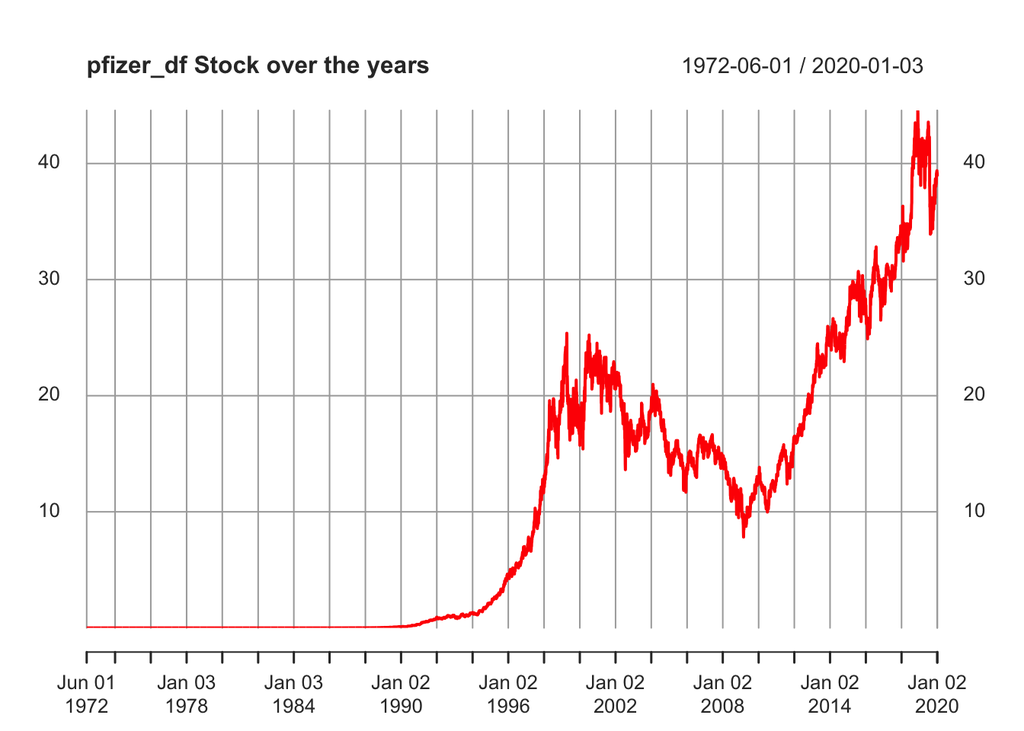

```r
library(lubridate) # Date manipulation
library(xts)   # For time series manipulation

pfizer_df$Date = as.Date(pfizer_df$Date, "%Y-%m-%d")
PFE = pfizer_df[,c("Date", "Adj.Close")]
PFE_TS = xts(PFE[,-1], order.by=as.Date(PFE[,1], "%m/%d/%Y"))
plot(PFE_TS,
     main="pfizer_df Stock over the years",
     col = "red")
```

## 2.12 apply functions

**apply()**, operates on arrays (for simplicity we limit here to 2D arrays, aka, matrices). If a dataframe is passed it will be coerced to array via as.matrix

We will use pfizer_df data to get the mean of data

```r
pfizer_subset_df = pfizer_df[,c(2:7)]
apply(pfizer_subset_df, 2, mean) #1 for row, 2 for col
```

```
##         Open         High          Low        Close    Adj.Close       Volume
## 1.579338e+01 1.595875e+01 1.562136e+01 1.579256e+01 1.005849e+01 1.763636e+07
```

### 2.12.1 lapply

**lapply()** function is applied for operations on list objects and returns a list object of same length of original set.

lapply function in R, returns a list of the same length as input list object, each element of which is the result of applying FUN to the corresponding element of list. If a dataframe is passed it will be coerced to list via as.list

```r
class(lapply(pfizer_subset_df, mean))
```

```
## [1] "list"
```

```r
lapply(pfizer_subset_df, mean)
```

```
## $Open
## [1] 15.79338
##
## $High
## [1] 15.95875
##
## $Low
## [1] 15.62136
##
## $Close
## [1] 15.79256
##
## $Adj.Close
## [1] 10.05849
##
## $Volume
## [1] 17636361
```

### 2.12.2 lapply with user defined function

A user defined function to plot a data.

```r
plot_fun = function(input)
  plot(input, col = 'blue',
       main = paste("plot of", names(input), sep = "-"))
```

Let us plot Closed and Adjusted Closed Values of Pfizer.

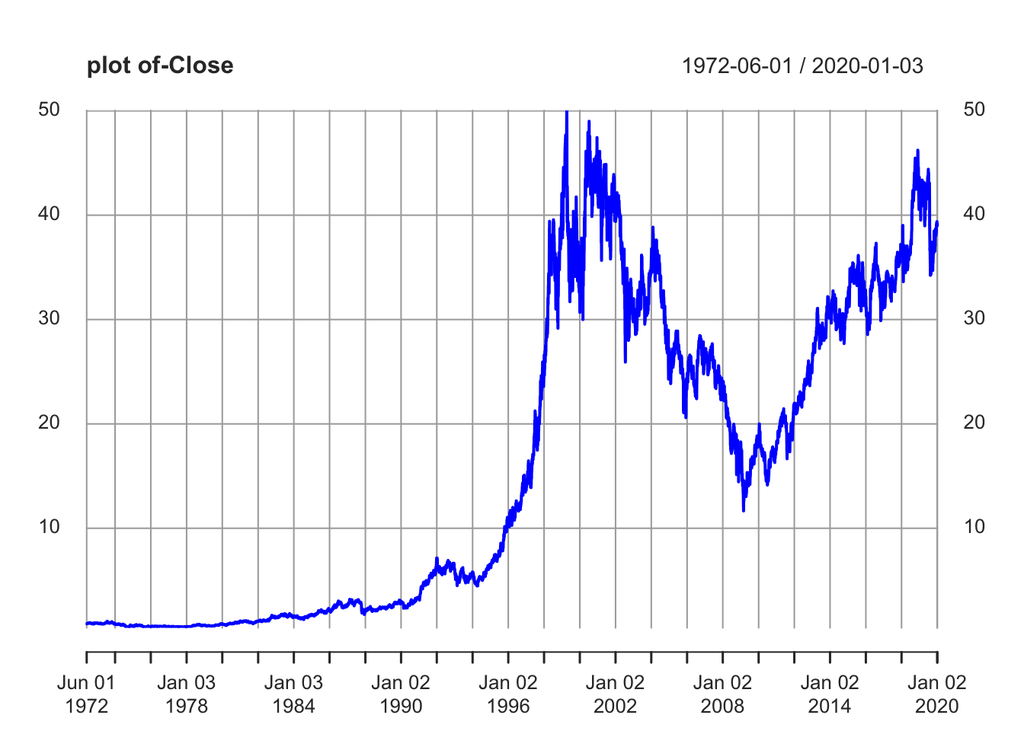

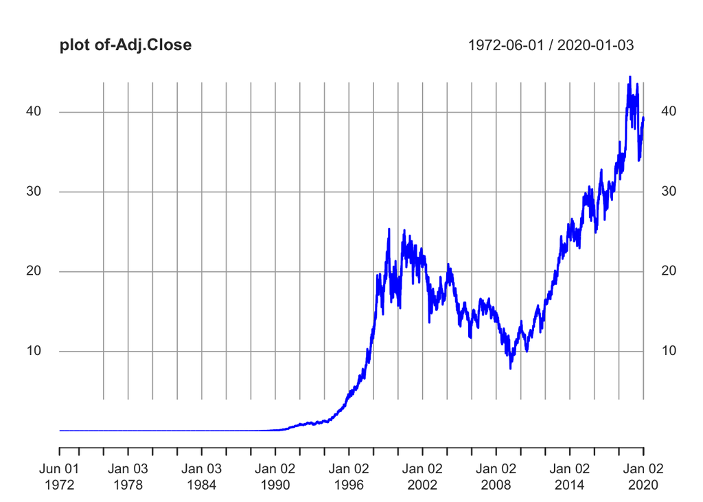

```r
library(xts)
PFE = pfizer_df[,c("Date", "Close","Adj.Close")]
PFE_TS = xts(PFE[,-1], order.by=as.Date(PFE[,1], "%m/%d/%Y"))
lapply(PFE_TS, plot_fun)
```

### 2.12.3 sapply

**sapply()** is wrapper class to lapply with difference being it returns vector or matrix instead of list object.

```r
#class(sapply(pfizer_df_subset_df, mean))
sapply(pfizer_subset_df, mean)
```

```
##         Open         High          Low        Close    Adj.Close       Volume
## 1.579338e+01 1.595875e+01 1.562136e+01 1.579256e+01 1.005849e+01 1.763636e+07
```

### 2.12.4 tapply

tapply() is a very powerful function that lets you break a vector into pieces and then apply some function to each of the pieces.

In the below code, first each of Adj.Close in pfizer_df data is grouped by Month and then mean() function is calculated.

```r
tapply(pfizer_df$Adj.Close,pfizer_df$Month, mean)
```

```
##         1         2         3         4         5         6         7         8
##  9.667102  9.984000  9.961855 10.202407 10.253194  9.976144 10.068055  9.974289
##         9        10        11        12
##  9.894537 10.150465 10.270159 10.291626
```

The data type of the object is

```r
class(tapply(pfizer_df$Adj.Close,pfizer_df$Month, mean))
```

```
## [1] "array"
```

## 2.13 Central Limit Theorem

**This is optional topic.** We will use the pfizer_df data for the demo.

```r
#Calculating Monthly return as a random variable
nrows = nrow(pfizer_df)
returns = c()
Closes = pfizer_df$Adj.Close
for (i in 1:(nrows-1)) {
  returns[i+1] = (Closes[i+1] - Closes[i]) / Closes[i]
}
returns[1] = returns[2]
pfizer_df$Return = returns
```

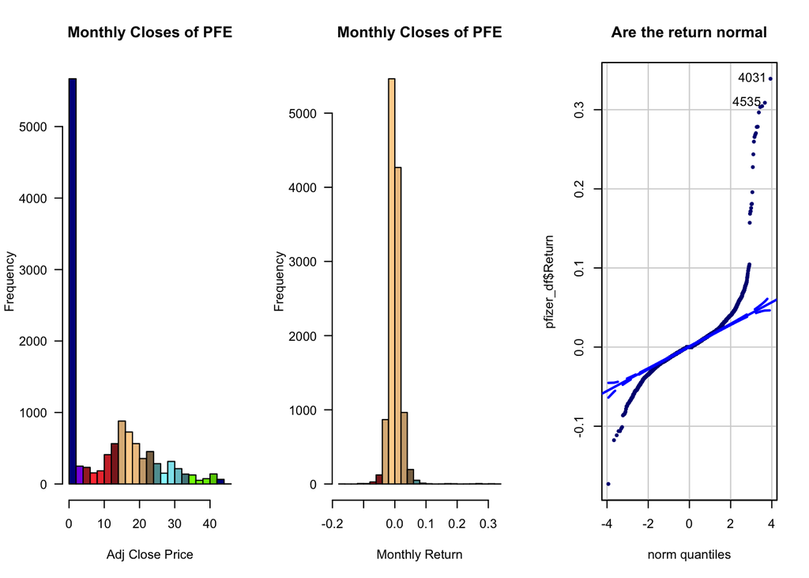

```
## [1] 4031 4535
```

```r
library(car) #for qqPlot
#To show normal distribution using pfizer_df data

par(mfrow=c(1,3)) # to make three plot on same row
hist(pfizer_df$Adj.Close,
     breaks = 30,
     col = colors()[30:50],
     main = "Monthly Closes of PFE",
     xlab = "Adj Close Price",
     las = 1)

#Plotting Monthly return
hist(pfizer_df$Return,
     breaks = 30,
     col = colors()[30:50],
     main = "Monthly Closes of PFE",
     xlab = "Monthly Return",
     las = 1)

qqPlot(pfizer_df$Return,
       main = "Are the return normal",
       pch = 20, cex = 0.7, col="navy")
```

See the observation with return actually zero

```r
knitr::kable(head(subset(pfizer_df, pfizer_df$Return == 0)))
```

|  | Date | Open | High | Low | Close | Adj.Close | Volume | Month | Year | Return |
| --- | --- | --- | --- | --- | --- | --- | --- | --- | --- | --- |
| 5 | 1972-06-07 | 0.864583 | 0.864583 | 0.851563 | 0.864583 | 0.000604 | 979200 | 6 | 1972 | 0 |
| 10 | 1972-06-14 | 0.875000 | 0.880208 | 0.869792 | 0.875000 | 0.000611 | 1963200 | 6 | 1972 | 0 |
| 19 | 1972-06-27 | 0.875000 | 0.882813 | 0.864583 | 0.875000 | 0.000611 | 1944000 | 6 | 1972 | 0 |
| 28 | 1972-07-11 | 0.934896 | 0.945313 | 0.934896 | 0.934896 | 0.000653 | 2073600 | 7 | 1972 | 0 |
| 48 | 1972-08-08 | 0.921875 | 0.927083 | 0.916667 | 0.921875 | 0.000644 | 2280000 | 8 | 1972 | 0 |
| 52 | 1972-08-14 | 0.953125 | 0.958333 | 0.945313 | 0.953125 | 0.000666 | 3144000 | 8 | 1972 | 0 |

See the observation of the return between plus/minus one sigma

```r
mu = mean(pfizer_df$Return)
sigma = sd(pfizer_df$Return)
knitr::kable(head(subset(pfizer_df,Return>= (mu-sigma) & Return <= (mu+sigma))))
```

|  | Date | Open | High | Low | Close | Adj.Close | Volume | Month | Year | Return |
| --- | --- | --- | --- | --- | --- | --- | --- | --- | --- | --- |
| 1 | 1972-06-01 | 0.000000 | 0.859375 | 0.846354 | 0.859375 | 0.000600 | 2332800 | 6 | 1972 | -0.0116667 |
| 2 | 1972-06-02 | 0.859375 | 0.861979 | 0.846354 | 0.848958 | 0.000593 | 1531200 | 6 | 1972 | -0.0116667 |
| 3 | 1972-06-05 | 0.848958 | 0.851563 | 0.841146 | 0.846354 | 0.000591 | 2452800 | 6 | 1972 | -0.0033727 |
| 5 | 1972-06-07 | 0.864583 | 0.864583 | 0.851563 | 0.864583 | 0.000604 | 979200 | 6 | 1972 | 0.0000000 |
| 6 | 1972-06-08 | 0.864583 | 0.867188 | 0.859375 | 0.859375 | 0.000600 | 1012800 | 6 | 1972 | -0.0066225 |
| 7 | 1972-06-09 | 0.859375 | 0.867188 | 0.859375 | 0.864583 | 0.000604 | 1483200 | 6 | 1972 | 0.0066667 |

Subset the data to get the records with return between 10 percent and 15 percent

```r
knitr::kable(head(subset(pfizer_df,Return>= 0.1 & Return <= 0.15)))
```

|  | Date | Open | High | Low | Close | Adj.Close | Volume | Month | Year | Return |
| --- | --- | --- | --- | --- | --- | --- | --- | --- | --- | --- |
| 3888 | 1987-10-21 | 2.291667 | 2.411458 | 2.291667 | 2.354167 | 0.008830 | 27043200 | 10 | 1987 | 0.1023720 |
| 5543 | 1994-05-09 | 4.937500 | 5.010417 | 4.937500 | 4.958333 | 1.376929 | 6292800 | 5 | 1994 | 0.1045192 |
| 9178 | 2008-10-13 | 16.469999 | 16.910000 | 15.880000 | 16.680000 | 10.764981 | 106278000 | 10 | 2008 | 0.1017172 |

## 2.14 Thank you

Practice on the exercises given and redo all the example codes given here using R.